# Average size of types in Wikidata

Egon

25 april 2019

## Number of statements per type

Following up on a question on the scalability of Wikidata, it was said on IRC that one of the current bottlenecks is the size of items, and more that than the number of items. We got to talk about Wikicite, and I wondered about the size of typical types of items, like a scholarly articles, an author, a chemical, a gene, and maybe a book.

### Installing the dependencies

If you do not have them installed, you need to get the following packages:

```r
library(SPARQL)
library(ggplot2)
```

### Helper function

We can define a helper function that uses SPARQL to get the statement counts:

```r
getCounts <- function(type="Q11173", sampleSize=10, typeClass=1) {
  query = paste(
    "SELECT ?statementcount WITH {",
    "  SELECT DISTINCT ?obj WHERE {",
    "    ?obj wdt:P31/wdt:P279* wd:", type, " .",
    "  } LIMIT ", sampleSize,
    "} AS %objects {",
    "  INCLUDE %objects",
    "  ?obj wikibase:statements ?statementcount",
    "}", sep=""
  )
  counts = SPARQL(
    "https://query.wikidata.org/bigdata/namespace/wdq/sparql",
    query
  )$results
  newData = cbind(rep(typeClass,length(counts)), t(counts))
  row.names(newData) = c()
  return(newData)
}
```

## General classes

We first sample the number of statements for things in a short series:

```r
wikidataTypes = data.frame(
  qids=c("Q11173","Q13442814","Q121594"),
  labels=c("Compounds", "Articles", "Professors")
)
for (i in 1:nrow(wikidataTypes)) {
  allData = rbind(allData, getCounts(wikidataTypes[i,"qids"], sampleSize, typeClass=i))
}
allDF = data.frame(Type=allData[,1], Statements=allData[,2])
allDF$Type <- factor(allDF$Type, labels = wikidataTypes$labels)
```

We can the plot the results:

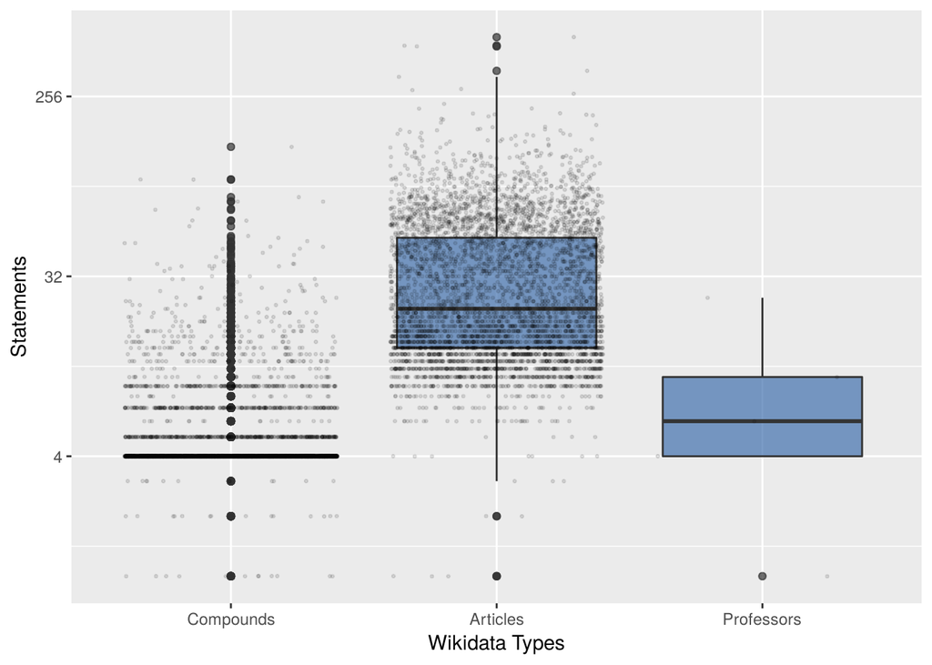

```r
p10 <- ggplot(allDF, aes(x = Type, y = Statements)) +
       geom_boxplot(fill="#4271AE", alpha = 0.7) +
       scale_y_continuous(trans='log2') +
       scale_x_discrete(name = "Wikidata Types") +
       geom_jitter(alpha=0.1, size=0.5)
p10
```

## Scholia classes

We first sample the number of statements for things in a short series:

```r
allData = c()
wikidataTypes = data.frame(
  qids=c("Q11173","Q13442814","Q5", "Q7187", "Q2431196", "Q17350442", "Q43229", "Q1656682", "Q16521", "Q486972"),
  labels=c("Compound", "Article", "Human", "Gene", "Audiovisual", "Venue", "Organization", "Event", "Taxon", "Settlement")
)
for (i in 1:nrow(wikidataTypes)) {
  allData = rbind(allData, getCounts(wikidataTypes[i,"qids"], sampleSize, typeClass=i))
}
allDF = data.frame(Type=allData[,1], Statements=allData[,2])
allDF$Type <- factor(allDF$Type, labels = wikidataTypes$labels)
```

We can the plot the results:

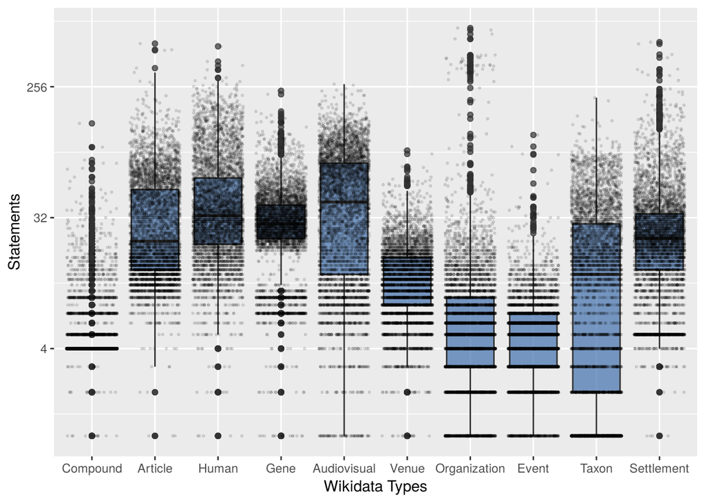

```r
p10 <- ggplot(allDF, aes(x = Type, y = Statements)) +
       geom_boxplot(fill="#4271AE", alpha = 0.7) +
       scale_y_continuous(trans='log2') +
       scale_x_discrete(name = "Wikidata Types") +
       geom_jitter(alpha=0.1, size=0.5)
p10
```